# Incarceration Across King County, Washington

Christine Nguyen

Info 201 AD - Winter Quarter 2021

### Introduction:

The primary incarceration data and trends used for this project was gathered by the Vera Institute of Justice from two primary sources: the Bureau of Justice Statistics and the Annual Survey of Jails. All the data sources can be found at https://github.com/vera-institute/incarceration-trends. The data in this project has since been manipulated and reduced to showcase underlying trends within King County, Washington.

King County was selected for this project for its diversity. While it varies depending on the location within the county, the general diversity and associated incarceration trends can serve as an example for what might found in other U.S. metropolitan areas.

### Summary Information:

The ratio of Black people in incarceration to the total Black population in King County was nearly five times that of the White population in King County, and 17 times that of the smallest ratio. In a fair society, we would expect these ratios to be fairly similar across the board. However, the United States continues to grapple with structural racism and inequities in its integrity.

In attempts to adjust for confounding variables, I pulled ratios of the incarcerated racial group in King County to the total incarcerated population in each given year. The following ratios were 0.0537712 for AAPI’s in King County, 0.3084804 for the Black community, 0.0576046 for the Latinx community, 0.0264706 for Indigenous communities, and 0.5115425 for the White population. We see that the some ratios level out and become closer to that of other communities, but still, there are drastic disparities across other racial groups that we cannot assume are naturally occurring. Marginalization, racial profiling, and unequal distribution of resources are just a few things that contribute to these varying ratios. With new information being shared about these issues, it is imperative that our society, from its leadership to its citizens, truly recognizes them as issues and works to address them.

### Showcasing Trends:

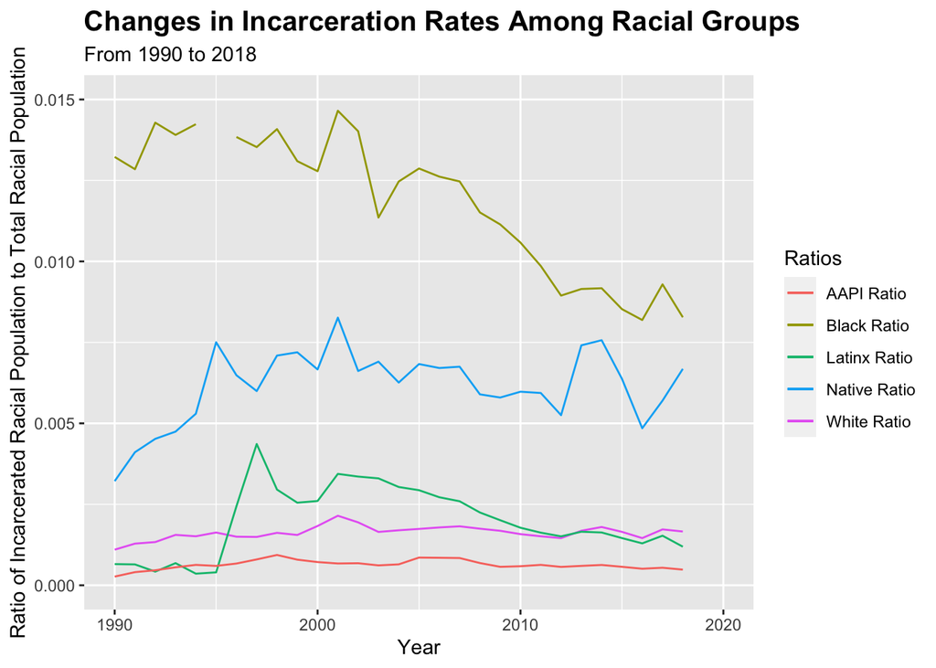

This graph shows the changes in ratios of an incarcerated racial group to its entire population in King County. It’s fair to assume none of the trend lines will ever be straight across, but it’s interesting to see how they change over the years. Some linger in the same range while others show peaks that coincide with that of other racial groups. By showcasing the trend lines on one graph, we can see how they differ from each other and how they change over time. It raises questions of why some peak and others don’t, and what events those peaks align with. These are questions that have yet to be answered by data, and perhaps with further research, we can come to an answer.

### Showcasing Relationships:

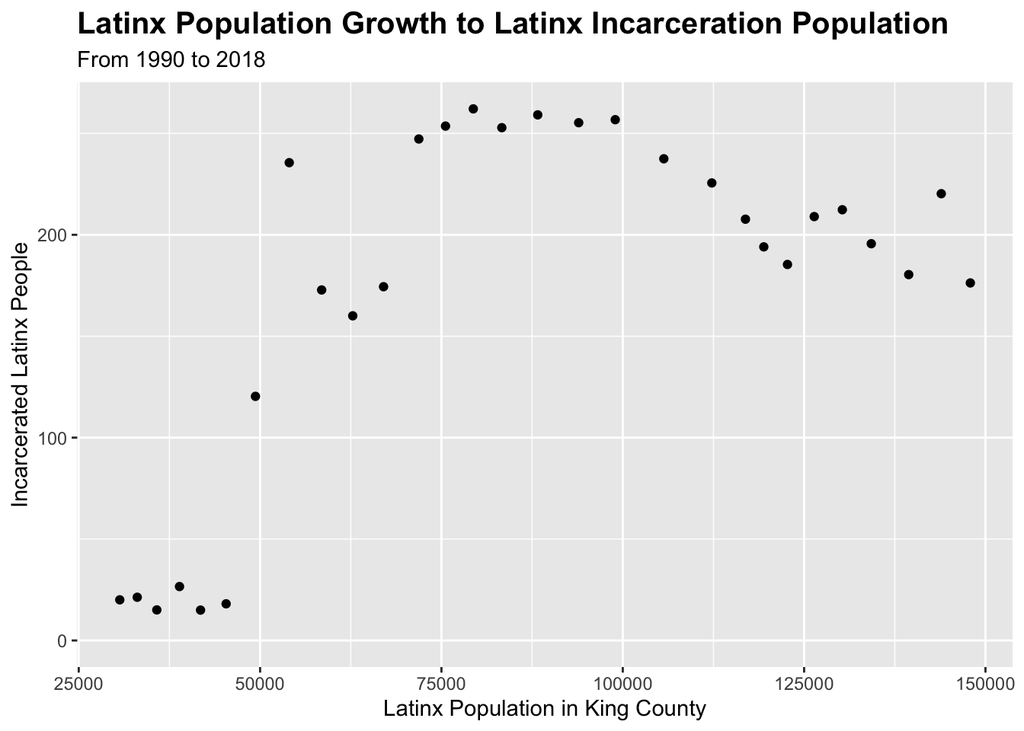

### Map:

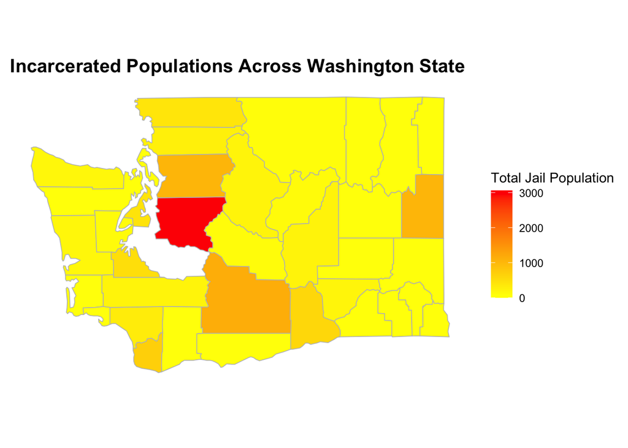

Featured is a chart of Washington state with all of its counties. The color scale refers to the total incarcerated population in each county. The larger the population, the darker the color. As we can see, King County has the highest count of incarcerated people. While this is alarming, it should be recognized that King County is the largest county in the state. Moving outside of King County, the county population drops, and so does the the number of people in jails.